# Bad Bunny

Author

Luisa Bernhardt

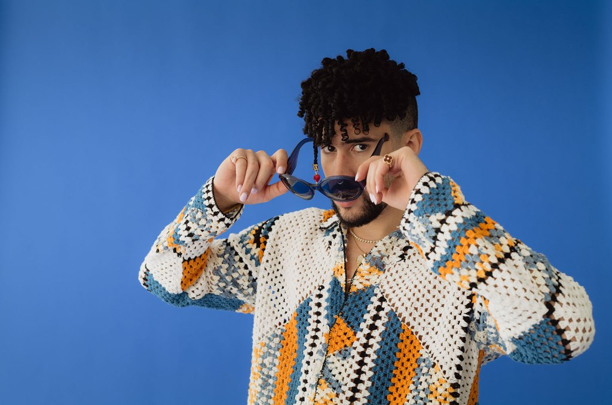

## Who is Bad Bunny?

Bad Bunny is the global phenomenon redefining modern Latin music. Born Benito Antonio Martínez Ocasio in Puerto Rico, the chart-topping superstar rose from humble beginnings to become one of the most influential artists of his generation. Known for his genre-blending sound, fearless fashion, and boundary-pushing lyrics, he has transformed reggaeton and Latin trap into a worldwide cultural force.

As a multi-platinum global reording artist and 7x GRAMMY winner, he has reshaped contemporary music and culture. Being Spotify’s most-streamed artist for four consecutive years, he became the first ever artist to top Spotify’s Global Wrapped list four times. “DeBÍ TiRAR MáS FOToS” became the first fully Spanish-language album to win the GRAMMY®️ Award for Album of the Year, marking a historic milestone for Latin music on the global stage.

Beyond the charts, he stands out as a cultural icon, using his voice to champion individuality, inclusivity, and social awareness. In 2026, he brought the first fully Spanish Super Bowl halftime show to the US, which evoked wide-spread criticism from conservative forces in the US.

For brands, fans, and music lovers alike, Bad Bunny represents more than an artist - he is a movement shaping the future of pop culture. Discover why the world can’t stop listening to the unstoppable force behind today’s biggest Latin music revolution.

## His albums

Since 2018, Bad Bunny has released the following eight albums:

[figure not shown]

X 100pre (2018)

[figure not shown]

Oasis (2019)

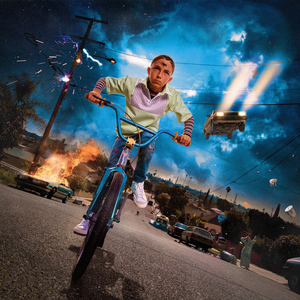

YHLQMDLG (2020)

[figure not shown]

Las que no iban a salir (2020)

[figure not shown]

El Último Tour del Mundo (2020)

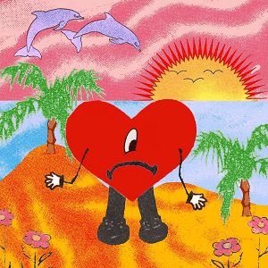

Un Verano Sin Ti (2022)

[figure not shown]

Nadie Sabe Lo Que Va a Pasar Mañana (2023)

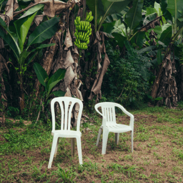

Debí Tirar Más Fotos (2025)

## My favorites

### My favorite lyrics

> *Debí tirar más fotos de cuando te tuve*

> *Debí darte más besos y abrazos las veces que pude*

> **‘DtMF’**

### My favorite song

BAILE INoLVIDABLE (2025, [YouTube link](https://www.youtube.com/watch?v=a1Femq4NPxs&list=RDa1Femq4NPxs&start_radio=1))

[video not shown]

### My favorite album

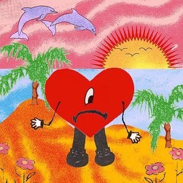

Un Verano Sin Ti (2022)

### My favorite live performance

Super Bowl Halftime Show 2026 ([YouTube link](https://www.youtube.com/watch?v=G6FuWd4wNd8&list=RDG6FuWd4wNd8&start_radio=1))

[video not shown]

## Data Analysis

### Data Source & Preparation

I retrieved the data of all songs published since 2020 from the provided server, and stored it in my project folder. Then, I added the album name and track number within the album to each song entry.

```r
# install all necessary R packages
library("ggplot2")
library("dplyr")
library("knitr")

# Import the data
DataFrame <- read.csv("DataBadBunny.csv")
```

```r
# Remove duplicates - if songs are published both as a single and as part of an album, remove the single
DataFrame <- DataFrame |> arrange(Song, desc(Album != "Single")) |> distinct(Song, .keep_all = TRUE)

# Change the data type of column "Album" from factor to character
DataFrame$Album <- as.character(DataFrame$Album)

# Define a chronological order of the albums
album_order <- c("Single", "YHLQMDLG", "LAS QUE NO IBAN A SALIR", "EL ÚLTIMO TOUR DEL MUNDO", "Un Verano Sin Ti", "nadie sabe lo que va a pasar mañana", "DeBÍ TiRAR MáS FOToS")
DataFrame <- DataFrame |>
  mutate(Album = factor(Album, levels = album_order))
```

```r
# Create dataframes ordered by album
# Singles
Singles <- DataFrame %>%
  filter(Album == "Single")

# YHLQMDLG
YHLQMDLG <- DataFrame %>%
  filter(Album == "YHLQMDLG")

#El Último Tour Del Mundo
ElUltimoTourDelMundo <- DataFrame %>%
  filter(Album == "EL ÚLTIMO TOUR DEL MUNDO")

# LAS QUE NO IBAN A SALIR
LasQueNoIbanASalir <- DataFrame %>%
  filter(Album == "LAS QUE NO IBAN A SALIR")

#nadie sabe lo que va a pasar mañana
NadieSabeLoQueVaAPasarMañana <- DataFrame %>%
  filter(Album == "nadie sabe lo que va a pasar mañana")

# Un Verano Sin Ti
UnVeranoSinTi <- DataFrame %>%
  filter(Album == "Un Verano Sin Ti")

# Debi Tirar Más Fotos
DebiTirarMasFotos <- DataFrame %>%
  filter(Album == "DeBÍ TiRAR MáS FOToS")
```

### The Data Frame

```r
# Slice 5 random records in the dataframe
DataFrame |> dplyr::slice_sample(n=5) |> knitr::kable(digits = 2)
```

| Song | Album | Track.number | Acousticness | Danceability | Energy | Instrumentalness | Liveness | Loudness | Speechiness | Tempo | Valence |
| --- | --- | --- | --- | --- | --- | --- | --- | --- | --- | --- | --- |
| FINA | nadie sabe lo que va a pasar mañana | 3 | 0.09 | 0.85 | 0.72 | 0 | 0.12 | -5.41 | 0.30 | 94.60 | 0.40 |
| De Museo | Single | 1 | 0.24 | 0.59 | 0.49 | 0 | 0.13 | -10.62 | 0.07 | 132.04 | 0.23 |
| Bichiyal | YHLQMDLG | 6 | 0.31 | 0.74 | 0.77 | 0 | 0.11 | -4.24 | 0.05 | 93.96 | 0.66 |
| Yo Perreo Sola - Remix | Single | 1 | 0.01 | 0.84 | 0.73 | 0 | 0.36 | -6.04 | 0.06 | 97.01 | 0.39 |
| Ojitos Lindos | Un Verano Sin Ti | 14 | 0.08 | 0.65 | 0.69 | 0 | 0.53 | -5.74 | 0.04 | 79.93 | 0.27 |

### Results

#### Danceability

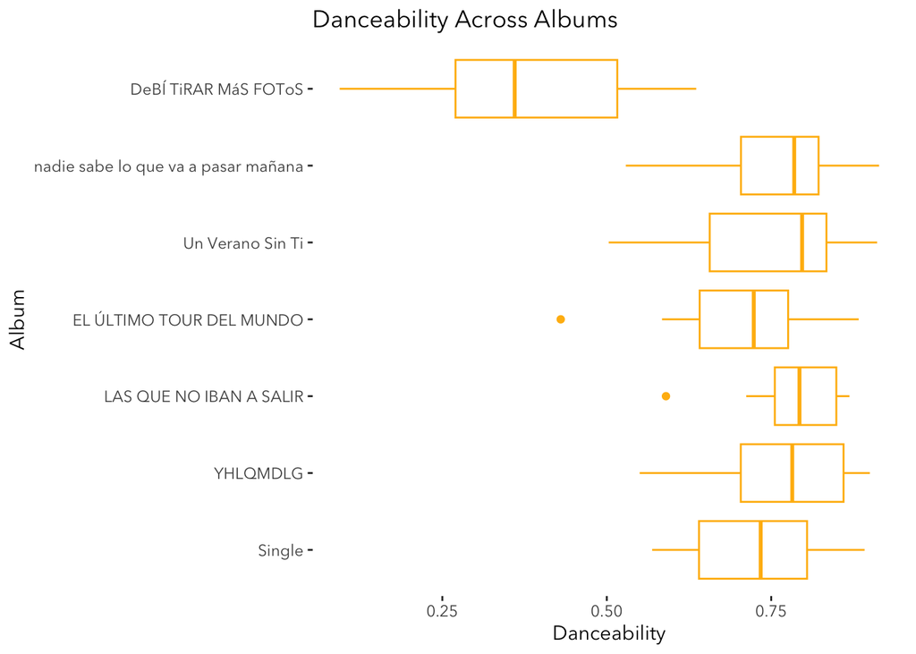

```r
DataFrame$Album <- factor(DataFrame$Album, levels = album_order)
ggplot(DataFrame, aes(x = Danceability, y = Album)) +
  geom_boxplot(color = "darkgoldenrod1") +
  labs(x = "Danceability", y = "Album", title = "Danceability Across Albums") +
  theme(panel.background = element_rect(fill = "transparent"),
        text = element_text(family = "Avenir Next"))
```

Bad Bunny’s latest album, *Debí Tirar Más Fotos*, scores unusually low in danceability. The album with the highest danceability is *Un Verano Sin Ti*.

#### Tempo

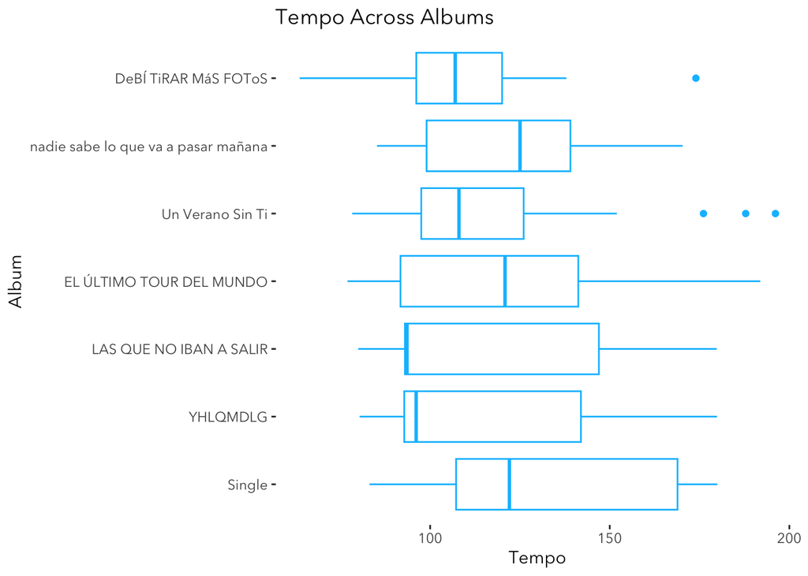

```r
DataFrame$Album <- factor(DataFrame$Album, levels = album_order)
ggplot(DataFrame, aes(x = Tempo, y = Album)) +
  geom_boxplot(color = "deepskyblue1") +
  labs(x = "Tempo", y = "Album", title = "Tempo Across Albums") +
  theme(panel.background = element_rect(fill = "transparent"),
        text = element_text(family = "Avenir Next"))
```

The tempo across his albums remains constant between around 100 and 135 bpm. No album is considerably slower or faster than the average.

#### Loudness

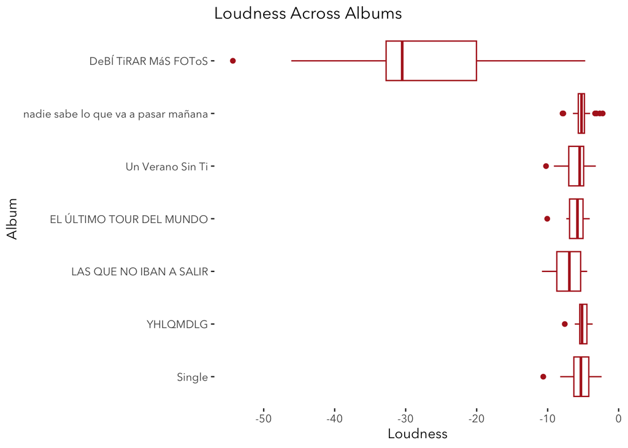

```r
DataFrame$Album <- factor(DataFrame$Album, levels = album_order)
ggplot(DataFrame, aes(x = Loudness, y = Album)) +
  geom_boxplot(color = "firebrick") +
  labs(x = "Loudness", y = "Album", title = "Loudness Across Albums") +
  theme(panel.background = element_rect(fill = "transparent"),
        text = element_text(family = "Avenir Next"))
```

While most of his albums are around -5 decibels loud, *Debí Tirar Más Fotos* is particularly quiet. This confirms the previous findings from the danceability score: his latest and most successful album seems to differ from his previous albums.

#### Valence

Next, I would like to determine which of his albums are the most and least positive. For this purpose, I analyze the valence of each album.

```r
# Create a dataframe with the mean valence of each album
Valence <- data.frame(
  Album = c("Single", "YHLQMDLG", "LAS QUE NO IBAN A SALIR", "EL ÚLTIMO TOUR DEL MUNDO", "Un Verano Sin Ti", "nadie sabe lo que va a pasar mañana", "DeBÍ TiRAR MáS FOToS"),
  AvgValence = c(mean(Singles$Valence), mean(YHLQMDLG$Valence), mean(LasQueNoIbanASalir$Valence), mean(ElUltimoTourDelMundo$Valence), mean(UnVeranoSinTi$Valence), mean(NadieSabeLoQueVaAPasarMañana$Valence), mean(DebiTirarMasFotos$Valence))
)
```

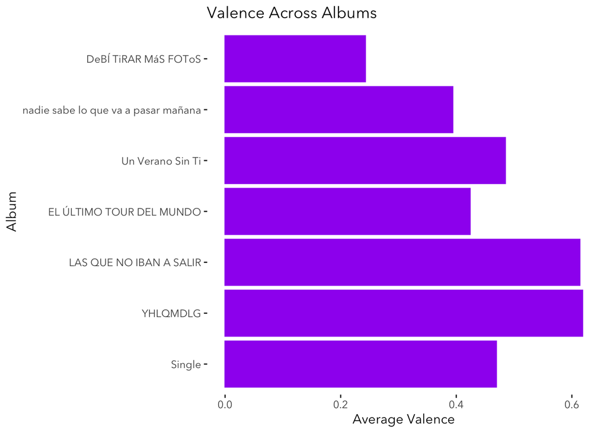

```r
# Create a bar chart with this new dataframe
Valence$Album <- factor(Valence$Album, levels = album_order)
ggplot(Valence, aes( x = AvgValence, y = Album)) +
  geom_bar(stat = "identity", color = "purple", fill = "purple") +
  labs(x = "Average Valence", title = "Valence Across Albums") +
  theme(panel.background = element_rect(fill = "transparent"),
        text = element_text(family = "Avenir Next"),
        )
```

A trend seems to emerge from these data: the valence decreases with the publication date - his newest and eighth album is only half as high in valence as his third album, *YHLQMDLG*.

#### Emotions - Combining Energy and Valence

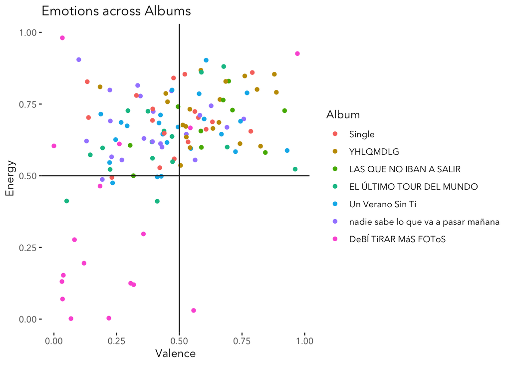

```r
ggplot(DataFrame, aes(x = Valence, y = Energy, color = Album)) +
  geom_point() +
  geom_hline(yintercept = 0.5, color = "grey16") +
  geom_vline(xintercept = 0.5, color = "grey16") +
  labs(x = "Valence", y = "Energy", title = "Emotions across Albums") +
  theme(panel.background = element_rect(fill = "transparent"),
        text = element_text(family = "Avenir Next"))
```

Together, energy and valence are indicators of the emotions a song conveys. The higher a song’s valence, the more positive it sounds. Energy indicates the intensity and activity of a song - the higher the energy, the faster, louder, and noisier the song. A song that scores high in both energy and valence is perceived as happy, whereas one with low energy and valence is perceived as sad. By contrast, a song with high energy and low valence conveys anger, while a song with low energy and high valence is perceived as peaceful.

With the exception of one song, Bad Bunny’s songs are not peaceful. Instead, the vast majority are either angry or happy (high energy with low or high valence). However, his album *Debí Tirar Más Fotos* is characterized by sad songs, which distinguishes it from his other albums.

#### 3 Most Positive Songs

```r
DataFrame |> slice_max(Valence, n=3) |> dplyr::select(Song, Album, Valence) |> knitr::kable(digits = 2)
```

| Song | Album | Valence |
| --- | --- | --- |
| LA MuDANZA | DeBÍ TiRAR MáS FOToS | 0.97 |
| CANTARES DE NAVIDAD | EL ÚLTIMO TOUR DEL MUNDO | 0.96 |
| Yo No Soy Celoso | Un Verano Sin Ti | 0.93 |

#### 3 Most Energetic Songs

```r
DataFrame |> slice_max(Energy, n=3) |> dplyr::select(Song, Album, Energy) |> knitr::kable(digits = 2)
```

| Song | Album | Energy |
| --- | --- | --- |
| VeLDÁ | DeBÍ TiRAR MáS FOToS | 0.98 |
| LA MuDANZA | DeBÍ TiRAR MáS FOToS | 0.93 |
| CYBERTRUCK | nadie sabe lo que va a pasar mañana | 0.90 |

### Analyzing Patterns within Albums

Now, I want to find out whether certain patterns emerge in the arrangement of songs within an album. Does Bad Bunny place his most energetic or danceable songs at the beginning of each album? Are the less positive songs found at the end?

Since all singles were assigned the track number 1, they would skew the results of my analysis. Therefore, I excluded them. I then analyzed the correlation between track number within an album and tempo, danceability, loudness, speechiness, valence, and energy.

```r
# Excluding all singles
NoSingles <- DataFrame %>%
  filter(Album != "Single")
```

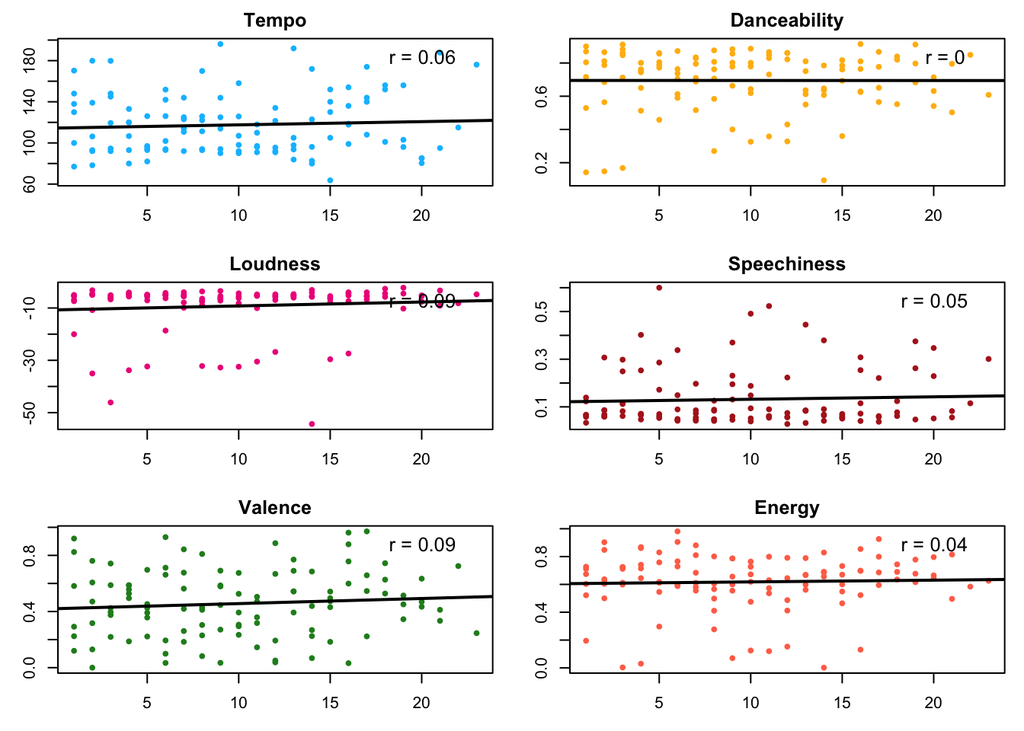

```r
# Correlations: track.number is the independent variable, tempo, danceability, loudness, speechiness, valence, and energy are the dependent variables

# Make a function that includes the scatterplot, the regression line, and the correlation coefficient
add_corr_plot <- function(x, y, title, color) {
  plot(x, y, xlab = "", ylab = "", main = title,
       pch = 19, cex = 0.6, col = color) # Scatterplot
  abline(lm(y ~ x), col = "black", lwd = 2) # Regr Line
  r_value <- round(cor(x, y, use = "complete.obs"), 2) # Corr Coeff
  mtext(paste("r =", r_value), side = 3, line = -1.5, adj = 0.9, cex = 0.8) # text placement
}

# Define the number of rows and columns, and set the margins
par(mfrow = c(3, 2), mar = c(3, 3, 2, 1))

# Plot each variable
add_corr_plot(NoSingles$Track.number, NoSingles$Tempo, "Tempo", "deepskyblue1")
add_corr_plot(NoSingles$Track.number, NoSingles$Danceability, "Danceability", "darkgoldenrod1")
add_corr_plot(NoSingles$Track.number, NoSingles$Loudness, "Loudness", "deeppink2")
add_corr_plot(NoSingles$Track.number, NoSingles$Speechiness, "Speechiness", "firebrick")
add_corr_plot(NoSingles$Track.number, NoSingles$Valence, "Valence", "forestgreen")
add_corr_plot(NoSingles$Track.number, NoSingles$Energy, "Energy", "coral1")
```

The track number of each song on an album does not correlate with any musical feature of his songs. Bad Bunny appears to have no systematic approach to song arrangement within an album based on tempo, danceability, loudness, speechiness, valence, or energy.